# Carbo-loading Data Wrangling with R

Varsha Agarwalla

December 9, 2018

## Carbo Loading Analysis

### Introduction

#### What am I trying to do?

I am looking at the carbo-loading household level transactions over a period of two years from four categories- Pasta, Pasta Sauce, Syrup, and Pancake Mix.

Based on the richness of the data, I want to know:

1. Are complementary products bought together?
2. if product sales depend on the display?

#### How to go about this?

I will look at the household-week level transactions for the product categories- pasta and pasta sauce and see if I can identify a pattern in the items bought across the weeks.

I will slice the data at product, week, store, display_desc, and sales level. Then I will see the trend for each product to see if we observe any pattern in sales based on the location of temporary in-store.

#### How will this be useful?

1. This analysis will help retailer design marketing campaigns for the complementary products.
2. The product display will help understand how customers make a decision and how display causes impact on the choice a customer makes.

### Packages Required

```r
library(tidyverse)  #to visualize, transform, input, tidy and join data
library(haven)      #to input data from SAS
library(dplyr)      #data wrangling
library(stringr)    #string related functions
library(kableExtra) #to create HTML Table
library(DT)         #to preview the data sets
library(lubridate)  #to apply the date functions
library(arules)     #to represent, manipulate and analyze transactional data
```

### Data Preparation

#### Data source

We obtained the **carbo-loading** household level data, obtained through the loyalty card program of a leading US grocer. It contains four data-sets, and was obtained from [here](http://uc-r.github.io/data_wrangling/final-project). Please see the code book at the same location.

1. *transactions* : household level data over a period of two years from four categories: Pasta, Pasta Sauce, Syrup, and Pancake Mix.

| Variable | Description |
| --- | --- |
| upc | Standard 10 digit UPC. |
| dollar_sales | Amount of dollars spent by the consumer |
| units | Number of products purchased by the consumer |
| time_of_transaction | The time of transaction(military time) |
| geography | Distinguishes between two large geographical regions, possibly values are 1 or 2 |
| week | Week of the transaction, values are from 1 to 104 |
| household | Unique households |
| store | Unique stores |
| basket | Unique baskets/trips to store |
| day | day of the transaction, possible values are from 1 to 728 |
| coupon | Indicates coupon usage, 1 if used, 0 otherwise |

2. *product lookup* : detailed product information

| Variable | Description |
| --- | --- |
| upc | Standard 10 digit UPC. |
| product_description | Description of product |
| commodity | specifies the four product categories under consideration |
| brand | Specific brand of item |
| product_size | Specifies package size of product |

3. *causal lookup* : trade activity for each product/week

| Variable | Description |
| --- | --- |
| upc | Standard 10 digit UPC. |
| store | Identifies unique store |
| week | Week of transaction, possible values are 1 through 104 |
| feature_desc | Describes product location on weekly mailer |
| display_desc | Describes temporary in-store display |
| geography | Distinguishes between two large geographical regions, possible values are 1 or 2 |

4. *store lookup* : store and it’s zip code

| Variable | Features |
| --- | --- |
| store | Identifies unique stores |
| store_zip_code | 5 digit zip code |

I load the four datasets-

```r
files <- c("causal_lookup", "product_lookup","store_lookup","transactions")
names <- c("causal_lookup","prd_lookup","store_lookup","transactions")

for (i in seq_along(files)) {
 df <- read_sas(paste0("data/",files[i],".sas7bdat"))
 assign(names[i], df)
 }
```

#### Data cleaning

1. UPC is 10 digit in length, so to keep it consistent across the four datasets, I padded *UPC* in the **product lookup** dataset, which originally had UPC of length 9 and 10

```r
unique(nchar(x = prd_lookup$upc))
## [1]  9 10
```

```r
prd_lookup_crtd <- prd_lookup
prd_lookup_crtd$upc <-  str_pad(prd_lookup$upc, 10, side = "left", pad = '0')
```

2. quantiles on the *dollar_sales* column to check for any absurdity in the data.

```r
quantile(transactions$dollar_sales, probs = seq(0, 1, 0.01))
##     0%     1%     2%     3%     4%     5%     6%     7%     8%     9%
## -11.76   0.44   0.50   0.50   0.52   0.55   0.59   0.67   0.69   0.75
##    10%    11%    12%    13%    14%    15%    16%    17%    18%    19%
##   0.79   0.79   0.79   0.79   0.80   0.85   0.88   0.89   0.89   0.90
##    20%    21%    22%    23%    24%    25%    26%    27%    28%    29%
##   0.99   0.99   0.99   0.99   0.99   0.99   0.99   0.99   0.99   0.99
##    30%    31%    32%    33%    34%    35%    36%    37%    38%    39%
##   1.00   1.00   1.03   1.09   1.09   1.18   1.19   1.19   1.19   1.25
##    40%    41%    42%    43%    44%    45%    46%    47%    48%    49%
##   1.25   1.29   1.30   1.37   1.39   1.45   1.49   1.50   1.50   1.50
##    50%    51%    52%    53%    54%    55%    56%    57%    58%    59%
##   1.50   1.53   1.58   1.58   1.58   1.59   1.59   1.60   1.65   1.67
##    60%    61%    62%    63%    64%    65%    66%    67%    68%    69%
##   1.69   1.78   1.79   1.85   1.90   1.98   1.98   1.99   1.99   1.99
##    70%    71%    72%    73%    74%    75%    76%    77%    78%    79%
##   1.99   1.99   2.00   2.00   2.18   2.19   2.25   2.29   2.38   2.45
##    80%    81%    82%    83%    84%    85%    86%    87%    88%    89%
##   2.49   2.50   2.55   2.69   2.69   2.79   2.89   2.99   2.99   2.99
##    90%    91%    92%    93%    94%    95%    96%    97%    98%    99%
##   3.00   3.18   3.19   3.34   3.49   3.59   3.98   4.00   4.77   5.70
##   100%
## 153.14
```

It seems like few data points are inconsistent with the other. So, I was interested in knowing if the data is actually skewed, so I ran the quantile function on units as well.

```r
quantile(transactions$units, probs = seq(0, 1, 0.01))
##   0%   1%   2%   3%   4%   5%   6%   7%   8%   9%  10%  11%  12%  13%  14%
##    1    1    1    1    1    1    1    1    1    1    1    1    1    1    1
##  15%  16%  17%  18%  19%  20%  21%  22%  23%  24%  25%  26%  27%  28%  29%
##    1    1    1    1    1    1    1    1    1    1    1    1    1    1    1
##  30%  31%  32%  33%  34%  35%  36%  37%  38%  39%  40%  41%  42%  43%  44%
##    1    1    1    1    1    1    1    1    1    1    1    1    1    1    1
##  45%  46%  47%  48%  49%  50%  51%  52%  53%  54%  55%  56%  57%  58%  59%
##    1    1    1    1    1    1    1    1    1    1    1    1    1    1    1
##  60%  61%  62%  63%  64%  65%  66%  67%  68%  69%  70%  71%  72%  73%  74%
##    1    1    1    1    1    1    1    1    1    1    1    1    1    1    1
##  75%  76%  77%  78%  79%  80%  81%  82%  83%  84%  85%  86%  87%  88%  89%
##    1    1    1    1    1    1    1    1    1    1    2    2    2    2    2
##  90%  91%  92%  93%  94%  95%  96%  97%  98%  99% 100%
##    2    2    2    2    2    2    2    2    3    3  156
```

I observe the same in units too.

Finally I looked at the transactions -

```r
transactions %>%
   mutate_all(as.vector) %>%
   filter( units > 100) %>%
   left_join(prd_lookup_crtd, by = "upc")
```

```
## # A tibble: 3 x 15
##   upc   dollar_sales units time_of_transac~ geography  week household store
##   <chr>        <dbl> <dbl> <chr>                <dbl> <dbl>     <dbl> <dbl>
## 1 9999~         118.   120 1400                     1    65    352180   102
## 2 2700~         153.   156 1541                     2    73     88418   270
## 3 9999~         132.   133 1500                     1    81    398723     9
## # ... with 7 more variables: basket <dbl>, day <dbl>, coupon <dbl>,
## #   product_description <chr>, commodity <chr>, brand <chr>,
## #   product_size <chr>
```

Since there are exactly **three** entries which tell us that more than 100 units of pasta sauce(mapped with the **prd_lookup_crtd** table to get the *commodity name*) were bought by the households at one time, which is not expected. There might be an issue with the data entry here, so I plan to drop these rows for my further analysis purpose.

3. special characters and different measurement units being used in the *product size* column in the **product lookup** dataset. However, I am not using it for my analysis.

#### Cleaned Datasets

1. After identifying the absurd data point, I removed its entry from the transactions. I also created a copy of the file to keep the original data as it is.

```r
#identifying the data index
which(transactions$units > 100)
## [1] 3127414 3522595 4020790

#cross-validating data at the index
transactions[c(3127414,3522595,4020790),]
## # A tibble: 3 x 11
##   upc   dollar_sales units time_of_transac~ geography  week household store
##   <chr>        <dbl> <dbl> <chr>                <dbl> <dbl>     <dbl> <dbl>
## 1 9999~         118.   120 1400                     1    65    352180   102
## 2 2700~         153.   156 1541                     2    73     88418   270
## 3 9999~         132.   133 1500                     1    81    398723     9
## # ... with 3 more variables: basket <dbl>, day <dbl>, coupon <dbl>

#deleting the row and creating another table so as to not mess with the original
transactions_crtd <- transactions[-c(3127414,3522595,4020790),]
```

Hence, the identified issues were fixed and thus the tables are ready to be used for further analysis.

*Please note: Instead of creating a master dataset with more than 15 columns, we plan to slice and dice and apply joins in the required data levels.*

#### Summary

1. A brief of the *transactions* data which will be majorly used for the entire analysis.

   |  | upc | dollar_sales | units | time_of_transaction | geography | week | household | store | basket | day | coupon |
   | --- | --- | --- | --- | --- | --- | --- | --- | --- | --- | --- | --- |
   | 1 | 7680850106 | 0.8 | 1 | 1100 | 2 | 1 | 125434 | 244 | 1 | 1 | 0 |
   | 2 | 3620000470 | 3.59 | 1 | 1100 | 2 | 1 | 125434 | 244 | 1 | 1 | 0 |
   | 3 | 1800028064 | 2.25 | 1 | 1137 | 2 | 1 | 108320 | 244 | 2 | 1 | 0 |
   | 4 | 9999985067 | 0.85 | 1 | 1148 | 2 | 1 | 162016 | 244 | 3 | 1 | 0 |
   | 5 | 9999985131 | 2.19 | 1 | 1323 | 2 | 1 | 89437 | 244 | 4 | 1 | 0 |
   | 6 | 5100002794 | 2.19 | 1 | 1323 | 2 | 1 | 89437 | 244 | 4 | 1 | 0 |
   | 7 | 1800000957 | 3.45 | 1 | 1415 | 2 | 1 | 158549 | 244 | 5 | 1 | 0 |
   | 8 | 9999985051 | 1.29 | 1 | 1415 | 2 | 1 | 158549 | 244 | 5 | 1 | 0 |
   | 9 | 9999985053 | 0.75 | 1 | 1513 | 2 | 1 | 18851 | 244 | 6 | 1 | 0 |
   | 10 | 3620000446 | 2.19 | 1 | 1523 | 2 | 1 | 118337 | 244 | 7 | 1 | 0 |

   [output cut: 10 more lines]

2. The unique number of UPCs that we will primarily use to join our tables: 927
3. All these UPCs are identified in the product_lookup table, so we can fetch the product, brand information

```r
transactions_crtd %>%
  mutate_all(as.vector) %>%
  anti_join(prd_lookup_crtd , by = "upc")
```

```
## # A tibble: 0 x 11
## # ... with 11 variables: upc <chr>, dollar_sales <dbl>, units <dbl>,
## #   time_of_transaction <chr>, geography <dbl>, week <dbl>,
## #   household <dbl>, store <dbl>, basket <dbl>, day <dbl>, coupon <dbl>
```

4. The different features avaiable in the data and are of interest- Wrap Interior Feature, Wrap Back Feature, Interior Page Feature, Not on Feature, Interior Page Line Item, Wrap Front Feature, Front Page Feature, Back Page Feature
5. The different temporary in-location display options avaiable: Not on Display, Rear End Cap, Store Rear, Front End Cap, In-Shelf, Store Front, Secondary Location Display, In-Aisle, Promo/Seasonal Aisle, Side-Aisle End Cap, Mid-Aisle End Cap
6. The sales and units by display_desc -

```
## # A tibble: 11 x 3
##    display_desc               total_sales total_units
##    <chr>                            <dbl>       <dbl>
##  1 Not on Display                 324395.      281389
##  2 Rear End Cap                    79471.       68814
##  3 In-Shelf                        63139.       51951
##  4 Front End Cap                   31889.       28086
##  5 Secondary Location Display      23581.       16422
##  6 In-Aisle                        21124.       16219
##  7 Promo/Seasonal Aisle            13619.       12359
##  8 Mid-Aisle End Cap               13288.       11084
##  9 Store Rear                      10016.        8349
## 10 Store Front                      6147.        5256
## 11 Side-Aisle End Cap               1835.        1250
```

I observe that for products that aren’t in display have more sales overall

7. The sales and units by feature_desc-

```
## # A tibble: 8 x 3
##   feature_desc            total_sales total_units
##   <chr>                         <dbl>       <dbl>
## 1 Interior Page Feature       240347.      196841
## 2 Not on Feature              172546.      136393
## 3 Front Page Feature          105429.      106489
## 4 Wrap Interior Feature        22507.       19338
## 5 Back Page Feature            17707.       17476
## 6 Wrap Front Feature           11098.       11210
## 7 Wrap Back Feature             9492.        7467
## 8 Interior Page Line Item       9378.        5965
```

I observe that for products that are featured in the interior page have more sales overall

### Exploratory Data Analysis

In this section, I started with initial data observation, tried to identify a buying pattern of complementary products and also looked at how sales differ based on the temporary in-store display of the products.

#### Initial Data Observations

Which brands are responsible for more sales within each commodity?(*Top 5*)

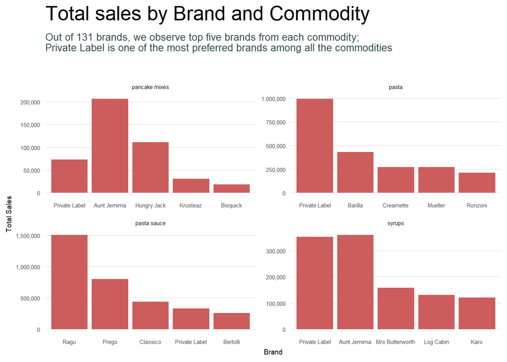

```r
#which brand is performing better
transactions_crtd %>%
  mutate_all(as.vector) %>%
  inner_join(prd_lookup_crtd, by = c("upc") ) %>%
  select(upc, week,store, geography, commodity, brand, dollar_sales,units) %>%
  group_by( commodity,brand) %>%
  summarize( total_sales = sum(dollar_sales), total_units = sum(units)) %>%
  arrange(desc(total_sales),desc(total_units)) %>%
  top_n(5, wt = total_sales) %>%
  ggplot( aes(x = reorder(brand,-total_sales), total_sales)) +
  geom_bar(stat = "identity", fill = "Indian red") +
  facet_wrap(~commodity, scales = "free") +
  scale_x_discrete("Brand") +
  scale_y_continuous("Total Sales",labels = scales::comma) +
  labs(title = "Total sales by Brand and Commodity",
             subtitle = "Out of 131 brands, we observe top five brands from each commodity; \nPrivate Label is one of the most preferred brands among all the commodities") +
  theme_minimal() +
  theme(panel.grid.minor = element_blank(),
        panel.grid.major.x = element_blank(),
        legend.title = element_blank(),
        legend.justification = c(0, 1),
        legend.position = c(.1, 1.075),
        legend.background = element_blank(),
        legend.direction="horizontal",
        text = element_text(family = "Georgia", size = 7),
        plot.title = element_text(size = 20, margin = margin(b = 10)),
        plot.subtitle = element_text(size = 10, color = "darkslategrey", margin = margin(b = 25)),
        plot.caption = element_text(size = 8, margin = margin(t = 10), color = "grey70", hjust = 0))
```

What is the preferrable shopping time?

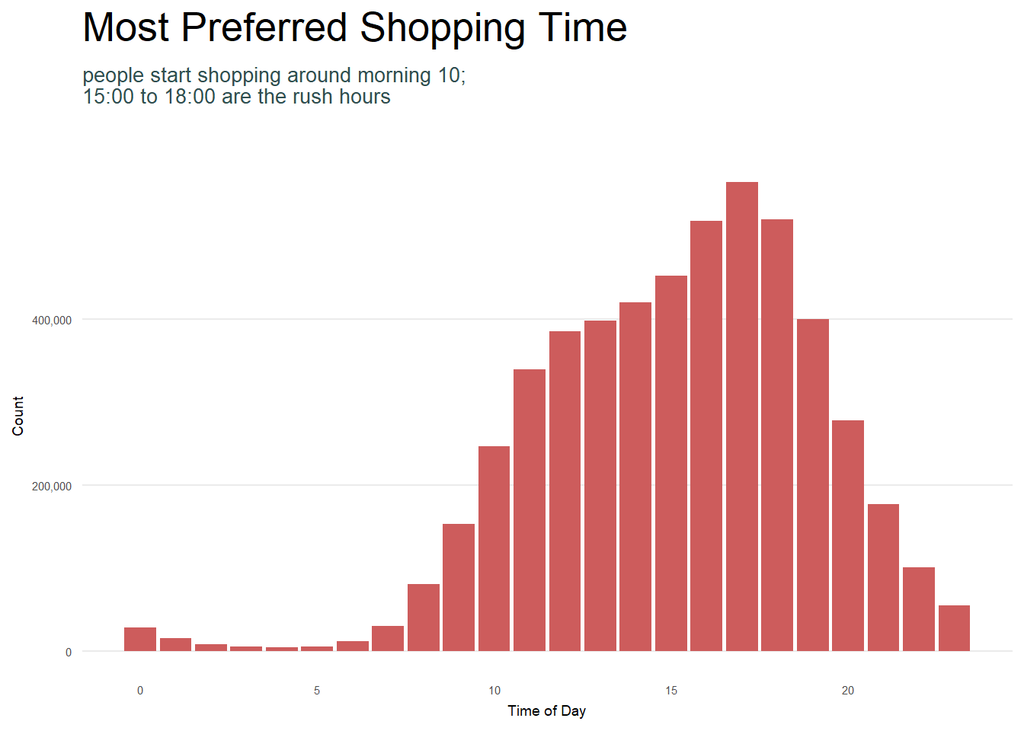

```r
transactions_crtd %>%
  ggplot(aes(x = time_of_transaction)) +
  geom_histogram(stat = "count",fill = "indianred") +
  theme(rect = element_blank()) +
  scale_x_continuous("Time of Day" ) +
  scale_y_continuous("Count",  labels = scales::comma) +
  labs(title = "Most Preferred Shopping Time",
             subtitle = "people start shopping around morning 10; \n15:00 to 18:00 are the rush hours") +
  theme_minimal() +
  theme(panel.grid.minor = element_blank(),
        panel.grid.major.x = element_blank(),
        legend.title = element_blank(),
        legend.justification = c(0, 1),
        legend.position = c(.1, 1.075),
        legend.background = element_blank(),
        legend.direction="horizontal",
        text = element_text(family = "Georgia", size = 7),
        plot.title = element_text(size = 20, margin = margin(b = 10)),
        plot.subtitle = element_text(size = 10, color = "darkslategrey", margin = margin(b = 25)),
        plot.caption = element_text(size = 8, margin = margin(t = 10), color = "grey70", hjust = 0))
```

Which items are sold more?

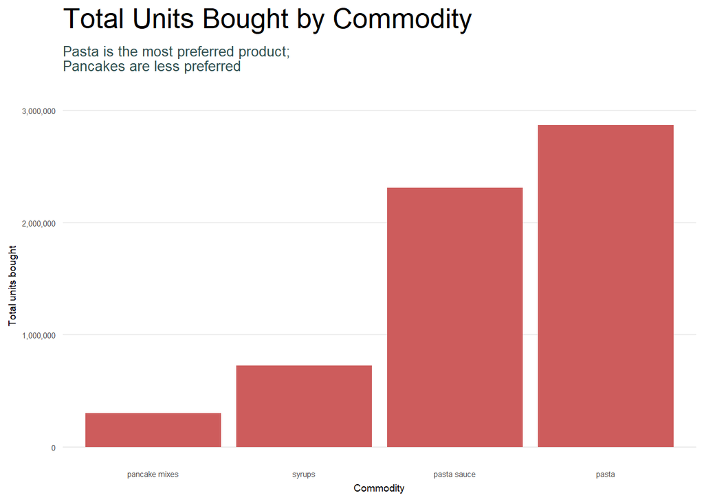

```r
transactions_crtd %>%
  mutate_all(as.vector) %>%
  filter(dollar_sales > 0) %>%
  inner_join(prd_lookup_crtd, by = c("upc") ) %>%
  select(upc, week,store, geography,
         commodity,basket, brand, dollar_sales,units) %>%
  group_by(commodity) %>%
  summarize(count = sum(units)) %>%
  arrange(desc(count)) %>%
  ggplot(aes(x=reorder(commodity,count), y=count))+
  geom_bar(stat="identity",fill="indian red")+
  scale_x_discrete("Commodity") +
  scale_y_continuous("Total units bought",labels = scales::comma) +
  labs(title = "Total Units Bought by Commodity",
             subtitle = "Pasta is the most preferred product; \nPancakes are less preferred") +
  theme_minimal() +
  theme(rect = element_blank()) +
  theme(panel.grid.minor = element_blank(),
        panel.grid.major.x = element_blank(),
        legend.title = element_blank(),
        legend.justification = c(0, 1),
        legend.position = c(.1, 1.075),
        legend.background = element_blank(),
        legend.direction="horizontal",
        text = element_text(family = "Georgia", size = 7),
        plot.title = element_text(size = 20, margin = margin(b = 10)),
        plot.subtitle = element_text(size = 10, color = "darkslategrey", margin = margin(b = 25)),
        plot.caption = element_text(size = 8, margin = margin(t = 10), color = "grey70", hjust = 0))
```

Since Pasta and Pasta Sauce happens to generate more sales, I would like to know -

A. if a relationship exists between the sales of complementary commodities (Pasta and Pasta Sauce)

B. if sales is dependent on the display of the product

#### Complementary Products

**Part A:** Checking if a relationship exists between the sales of complementary commodities (Pasta and Pasta Sauce)

I am using the basket analysis which uses **Association Rule Mining** to look for combinations of items that occur together frequently in transactions. It tells us which items customer frequently buys together by generating a set of rules. There are two statistical measures that can be used to determine whether or not a rule is deemed “interesting”

*Support*: Fraction of transactions that contain the item-set. If Support = 0.2, it means 20% of transaction show which A is bought with B

*Confidence*: It shows the percentage in which B is bought with A. If Confidence = 0.6; it means 60% of customers who purchase A also purchase B

```r
#filtered the data for geography 1 for the analysis
market <- transactions_crtd %>%
            left_join(prd_lookup_crtd, by="upc") %>%
            filter(geography == 1  ) %>%
            arrange(desc(commodity)) %>%
            select(basket,commodity) %>%
            distinct()

#using ddply package for ddply function
#The function ddply() accepts a data frame, splits it into pieces based on one or more factors, computes on the pieces, and then returns the results as a data frame
transactionData <- plyr::ddply(market,c("basket"),
                         function(market)paste(market$commodity,
                                            collapse = ","))

#removing all columns except for the items
transactionData$basket = NULL

colnames(transactionData) <- c("items")

#writing the transactional data in another file
write.csv(x = transactionData$items,
          file = "edited_transaction_required.csv",
          quote = FALSE, row.names = FALSE)

groceries <- read.transactions('edited_transaction_required.csv',
                               format = 'basket', sep=',', skip = 1)
summary(groceries)
```

```
## transactions as itemMatrix in sparse format with
##  1776754 rows (elements/itemsets/transactions) and
##  4 columns (items) and a density of 0.3359036
##
## most frequent items:
##         pasta   pasta sauce        syrups pancake mixes       (Other)
##       1042750        819467        364649        160406             0
##
## element (itemset/transaction) length distribution:
## sizes
##       1       2       3       4
## 1222469  506297   39743    8245
##
##    Min. 1st Qu.  Median    Mean 3rd Qu.    Max.
##   1.000   1.000   1.000   1.344   2.000   4.000
##
## includes extended item information - examples:
##          labels
## 1 pancake mixes
## 2         pasta
## 3   pasta sauce
```

So, we have 1,776,754 transactions containing 4 different items. We observe the count of transactions that involved an item. The second block of our output contains summary statistics about the size of each transaction. For example, there were 506,297 transactions in which only 2 items were bought and 8,245 transaction in which all 4 items were bought.

Below is a view of the transactions -

```r
inspect(groceries[1:10])
```

```
##      items
## [1]  {pancake mixes}
## [2]  {pasta}
## [3]  {pancake mixes,syrups}
## [4]  {pancake mixes}
## [5]  {pasta}
## [6]  {pasta,pasta sauce}
## [7]  {pasta}
## [8]  {pasta}
## [9]  {pancake mixes,syrups}
## [10] {pasta}
```

Let’s look at the frequency of items that are purchased-

```r
itemFrequency(groceries[, 1:4])
```

```
## pancake mixes         pasta   pasta sauce        syrups
##    0.09028037    0.58688485    0.46121579    0.20523325
```

We observe that only 9% of transaction involves pancake mixes whereas Pasta was bought in 58% of the transactions. Below is the plot for the same-

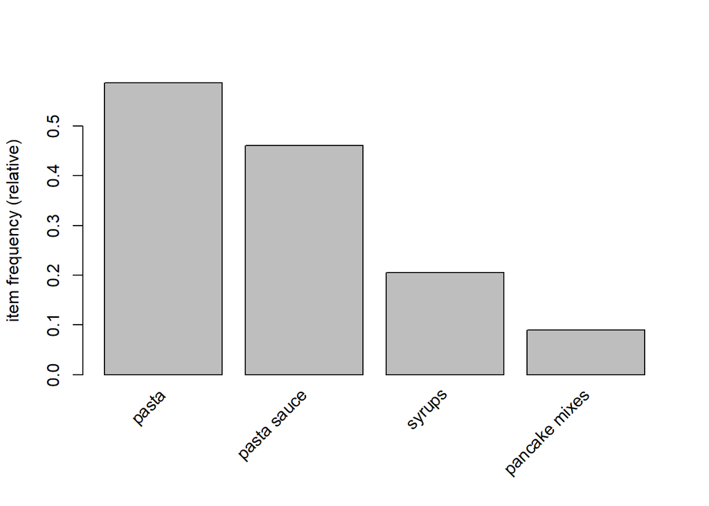

```r
itemFrequencyPlot(groceries, topN  = 4)
```

```r
#sorting on the decreasing order of confidence
rules <- sort(rules, by ='confidence', decreasing = TRUE)
summary(rules)
```

```
## set of 6 rules
##
## rule length distribution (lhs + rhs):sizes
## 1 2 3
## 1 1 4
##
##    Min. 1st Qu.  Median    Mean 3rd Qu.    Max.
##    1.00    2.25    3.00    2.50    3.00    3.00
##
## summary of quality measures:
##     support           confidence          lift            count
##  Min.   :0.009255   Min.   :0.5339   Min.   :0.9302   Min.   :  16444
##  1st Qu.:0.011355   1st Qu.:0.5504   1st Qu.:1.0138   1st Qu.:  20175
##  Median :0.017654   Median :0.5754   Median :1.0755   Median :  31367
##  Mean   :0.148749   Mean   :0.5822   Mean   :1.0769   Mean   : 264290
##  3rd Qu.:0.193256   3rd Qu.:0.6111   3rd Qu.:1.1422   3rd Qu.: 343368
##  Max.   :0.586885   Max.   :0.6432   Max.   :1.2227   Max.   :1042750
##
## mining info:
##       data ntransactions support confidence
##  groceries       1776754   0.005        0.5
```

We obtain 6 rules, out of which 4 rules are for the length of 3 items.

Let’s print all the rules-

```r
inspect_rules[,c(-1,-2,-3)] <- round(inspect_rules[,c(-1,-2,-3)],3)
datatable(inspect_rules)
```

|  | lhs | Var.3 | rhs | support | confidence | lift | count |
| --- | --- | --- | --- | --- | --- | --- | --- |
| [1] | {pancake mixes,pasta sauce} | =&gt; | {pasta} | 0.009 | 0.643 | 1.096 | 16444 |
| [2] | {pasta sauce,syrups} | =&gt; | {pasta} | 0.018 | 0.619 | 1.055 | 31367 |
| [3] | {} | =&gt; | {pasta} | 0.587 | 0.587 | 1 | 1042750 |
| [4] | {pancake mixes,pasta} | =&gt; | {pasta sauce} | 0.009 | 0.564 | 1.223 | 16444 |
| [5] | {pasta sauce} | =&gt; | {pasta} | 0.252 | 0.546 | 0.93 | 447368 |
| [6] | {pasta,syrups} | =&gt; | {pasta sauce} | 0.018 | 0.534 | 1.158 | 31367 |

They said- “*The combination might be unorthodox, but the contrast between sweet and savory couldn’t be more classic*”  
(*p.s. this is not based on any analysis* :P). You can read more about it [here](https://www.myrecipes.com/extracrispy/elf-is-right-about-maple-syrup-on-spaghetti)

*please note: Since the dataset is huge, I have filtered the data for geogrpahy = 1 in this analysis*

#### Role of Display

**Part B:** Checking impact of *display_desc* on the sales of commodities

I would like to see if average sales across the different display differ using ANOVA.

> Null hypothesis **Ho** : sales are independent of display of product  
> Alternate hypthesis **Ha** : sales are dependent on display

```r
#filtered the data for geography 1 for the analysis
#using the previously created dataset
trans_geo <- trans_cut %>%
              filter(geography == 1 )

#applying ANOVA
anova <- aov(tot_sales ~ display_desc, data = trans_geo)
summary(anova)
```

[output not shown]

[output not shown]

```
##                 Df Sum Sq Mean Sq F value Pr(>F)
## display_desc    10  31005  3100.5   462.7 <2e-16 ***
## Residuals    93638 627400     6.7
## ---
## Signif. codes:  0 '***' 0.001 '**' 0.01 '*' 0.05 '.' 0.1 ' ' 1
```

Since the p-value is < 0.05(the significance level), we can say reject the null hypothesis. Thus, ANOVA results tells that the sales is dependent on the display of the product and the results are significant overall, but it doesn’t tell us where those differences lie.

I use **TukeyHSD**(Honestly Singificant Difference) test to do pair-wise comparison and identify the ones that differ. It tells us which specific groups’s means are different.

When `p adj` is less than 0.05, we reject Ho and thus we can say that there is a significant difference in the sales in that particular pair of display.

```r
tukey_ouput <- TukeyHSD(anova, ordered = TRUE)
tukey_ouput <- tukey_ouput$display_desc %>%     #strips off some headers in kk
                        as.data.frame()
tukey_ouput <- round(tukey_ouput,5)
tukey_ouput_cut <- tukey_ouput[tukey_ouput$`p adj` < 0.05,]
datatable(tukey_ouput_cut, filter = 'top',
          options = list(pageLength = 12, autoWidth = TRUE ))
```

|  | diff | lwr | upr | p adj |
| --- | --- | --- | --- | --- |
| Promo/Seasonal Aisle-Not on Display | 0.52554 | 0.34441 | 0.70666 | 0 |
| Secondary Location Display-Not on Display | 0.70738 | 0.57395 | 0.84082 | 0 |
| Mid-Aisle End Cap-Not on Display | 0.81618 | 0.54911 | 1.08324 | 0 |
| In-Shelf-Not on Display | 1.17552 | 1.07654 | 1.27451 | 0 |
| Front End Cap-Not on Display | 1.20022 | 1.04208 | 1.35836 | 0 |
| Store Rear-Not on Display | 1.26639 | 1.05074 | 1.48204 | 0 |
| Rear End Cap-Not on Display | 1.34551 | 1.24995 | 1.44107 | 0 |
| In-Aisle-Not on Display | 1.46638 | 1.30893 | 1.62382 | 0 |
| Side-Aisle End Cap-Not on Display | 1.54596 | 1.08044 | 2.01148 | 0 |
| Store Front-Not on Display | 1.56743 | 1.29531 | 1.83955 | 0 |

[output cut: 26 more lines]

Therefore, we can clearly note an increase in difference of average sales for the ones which were on *Promo/Seasonal Aisle* than the ones which were *Not on Display*. Diference lies in 36 such pairs. This completely changes our initial observations.

*please note: Since the dataset is huge, I have filtered the data for geogrpahy = 1 in this analysis*

### Summary

**Problem Statement**

This analysis is intended to identify shopping pattern of customers and their preferences which would help retailers in generating more revenue and also enhance customers’ experience.

**Methodology**

1. In order to gain a clear understanding of the customers buying pattern, I used *Apriori Algorithm* to perform Market Basket Analysis. This technique helps us to uncover associations between items, by looking for combinations of items that occur togther in transactions and providing information to understand the purchase behavior
2. For identifying if sales depend on the in-store display of the products, I performed ANOVA test. ANOVA test tells us if the results are significant or not, but to identify where exactly the difference lies, I used *TukeyHSD* test

**Insights**

The analysis can be used to gain an understanding of customer’s journey while shopping. Clients can use the rules generated by the algorithm for numerous marketing strategies -

1. Changing the store layout
2. Customer behavior analysis
3. Catalogue(feature in mailer) design
4. Cross marketing
5. Customized emails with add-on samples
6. providing recommendations while online shopping

**Limitations**

This analysis was limited by the number of items in the data. In future, I would like to include more items and observe pattern in customers’ preference. I would also like to look at the top performing stores, identify reasons for their performances and build strategies for the ones that aren’t performing well comparatively.